# Project: Investigate on the gun sales trend in the US

## Introduction

In this project, the overall trend of gun purchases in the U.S. will be investigated, both nation-wise and the state-wise trend. Following that, the potential factors which contribute to the general gun sale will be investigated.

Information regarding data: The first data set ('gun_data.xlsx') comes from the FBI's National Instant Criminal Background Check System (NICS). This data is used by gun shops to determine the eligibility of a prospective firearms/explosive buyer.  
The second data set ('U.S. census data.csv') is the U.S census data.

### Import Relevant Libraries and Data

```python
import pandas as pd
import numpy as np
import matplotlib.pyplot as plt
import seaborn as sns
sns.set()

%matplotlib inline

df_gun = pd.read_excel('gun_data.xlsx', shee_tname='none')
df_census = pd.read_csv('U.S. Census Data.csv')
```

## Data Wrangling

### Investigate census_data

```python
df_census.head()
```

|  | Fact | Fact Note | Alabama | Alaska | Arizona | Arkansas | California | Colorado | Connecticut | Delaware | ... | South Dakota | Tennessee | Texas | Utah | Vermont | Virginia | Washington | West Virginia | Wisconsin | Wyoming |
| --- | --- | --- | --- | --- | --- | --- | --- | --- | --- | --- | --- | --- | --- | --- | --- | --- | --- | --- | --- | --- | --- |
| 0 | Population estimates, July 1, 2016, (V2016) | NaN | 4,863,300 | 741,894 | 6,931,071 | 2,988,248 | 39,250,017 | 5,540,545 | 3,576,452 | 952,065 | ... | 865454 | 6651194 | 27,862,596 | 3,051,217 | 624,594 | 8,411,808 | 7,288,000 | 1,831,102 | 5,778,708 | 585,501 |
| 1 | Population estimates base, April 1, 2010, (V2... | NaN | 4,780,131 | 710,249 | 6,392,301 | 2,916,025 | 37,254,522 | 5,029,324 | 3,574,114 | 897,936 | ... | 814195 | 6346298 | 25,146,100 | 2,763,888 | 625,741 | 8,001,041 | 6,724,545 | 1,853,011 | 5,687,289 | 563,767 |
| 2 | Population, percent change - April 1, 2010 (es... | NaN | 1.70% | 4.50% | 8.40% | 2.50% | 5.40% | 10.20% | 0.10% | 6.00% | ... | 0.063 | 0.048 | 10.80% | 10.40% | -0.20% | 5.10% | 8.40% | -1.20% | 1.60% | 3.90% |
| 3 | Population, Census, April 1, 2010 | NaN | 4,779,736 | 710,231 | 6,392,017 | 2,915,918 | 37,253,956 | 5,029,196 | 3,574,097 | 897,934 | ... | 814180 | 6346105 | 25,145,561 | 2,763,885 | 625,741 | 8,001,024 | 6,724,540 | 1,852,994 | 5,686,986 | 563,626 |
| 4 | Persons under 5 years, percent, July 1, 2016, ... | NaN | 6.00% | 7.30% | 6.30% | 6.40% | 6.30% | 6.10% | 5.20% | 5.80% | ... | 0.071 | 0.061 | 7.20% | 8.30% | 4.90% | 6.10% | 6.20% | 5.50% | 5.80% | 6.50% |

5 rows × 52 columns

```python
df_census.tail(25)
```

|  | Fact | Fact Note | Alabama | Alaska | Arizona | Arkansas | California | Colorado | Connecticut | Delaware | ... | South Dakota | Tennessee | Texas | Utah | Vermont | Virginia | Washington | West Virginia | Wisconsin | Wyoming |
| --- | --- | --- | --- | --- | --- | --- | --- | --- | --- | --- | --- | --- | --- | --- | --- | --- | --- | --- | --- | --- | --- |
| 60 | Veteran-owned firms, 2012 | NaN | 41,943 | 7,953 | 46,780 | 25,915 | 252,377 | 51,722 | 31,056 | 7,206 | ... | 8604 | 59379 | 213,590 | 18,754 | 8,237 | 76,434 | 49,331 | 12,912 | 39,830 | 6,470 |
| 61 | Nonveteran-owned firms, 2012 | NaN | 316,984 | 56,091 | 427,582 | 192,988 | 3,176,341 | 469,524 | 281,182 | 60,318 | ... | 66219 | 469392 | 2,057,218 | 219,807 | 63,317 | 548,439 | 461,401 | 94,960 | 370,755 | 51,353 |
| 62 | Population per square mile, 2010 | NaN | 94.4 | 1.2 | 56.3 | 56 | 239.1 | 48.5 | 738.1 | 460.8 | ... | 10.7 | 153.9 | 96.3 | 33.6 | 67.9 | 202.6 | 101.2 | 77.1 | 105 | 5.8 |
| 63 | Land area in square miles, 2010 | NaN | 50,645.33 | 570,640.95 | 113,594.08 | 52,035.48 | 155,779.22 | 103,641.89 | 4,842.36 | 1,948.54 | ... | 75811 | 41234.9 | 261,231.71 | 82,169.62 | 9,216.66 | 39,490.09 | 66,455.52 | 24,038.21 | 54,157.80 | 97,093.14 |
| 64 | FIPS Code | NaN | "01" | "02" | "04" | "05" | "06" | "08" | "09" | "10" | ... | "46" | "47" | "48" | "49" | "50" | "51" | "53" | "54" | "55" | "56" |
| 65 | NaN | NaN | NaN | NaN | NaN | NaN | NaN | NaN | NaN | NaN | ... | NaN | NaN | NaN | NaN | NaN | NaN | NaN | NaN | NaN | NaN |
| 66 | NOTE: FIPS Code values are enclosed in quotes ... | NaN | NaN | NaN | NaN | NaN | NaN | NaN | NaN | NaN | ... | NaN | NaN | NaN | NaN | NaN | NaN | NaN | NaN | NaN | NaN |
| 67 | NaN | NaN | NaN | NaN | NaN | NaN | NaN | NaN | NaN | NaN | ... | NaN | NaN | NaN | NaN | NaN | NaN | NaN | NaN | NaN | NaN |
| 68 | Value Notes | NaN | NaN | NaN | NaN | NaN | NaN | NaN | NaN | NaN | ... | NaN | NaN | NaN | NaN | NaN | NaN | NaN | NaN | NaN | NaN |
| 69 | 1 | Includes data not distributed by county. | NaN | NaN | NaN | NaN | NaN | NaN | NaN | NaN | ... | NaN | NaN | NaN | NaN | NaN | NaN | NaN | NaN | NaN | NaN |
| 70 | NaN | NaN | NaN | NaN | NaN | NaN | NaN | NaN | NaN | NaN | ... | NaN | NaN | NaN | NaN | NaN | NaN | NaN | NaN | NaN | NaN |
| 71 | Fact Notes | NaN | NaN | NaN | NaN | NaN | NaN | NaN | NaN | NaN | ... | NaN | NaN | NaN | NaN | NaN | NaN | NaN | NaN | NaN | NaN |
| 72 | (a) | Includes persons reporting only one race | NaN | NaN | NaN | NaN | NaN | NaN | NaN | NaN | ... | NaN | NaN | NaN | NaN | NaN | NaN | NaN | NaN | NaN | NaN |
| 73 | (b) | Hispanics may be of any race, so also are incl... | NaN | NaN | NaN | NaN | NaN | NaN | NaN | NaN | ... | NaN | NaN | NaN | NaN | NaN | NaN | NaN | NaN | NaN | NaN |
| 74 | (c) | Economic Census - Puerto Rico data are not com... | NaN | NaN | NaN | NaN | NaN | NaN | NaN | NaN | ... | NaN | NaN | NaN | NaN | NaN | NaN | NaN | NaN | NaN | NaN |
| 75 | NaN | NaN | NaN | NaN | NaN | NaN | NaN | NaN | NaN | NaN | ... | NaN | NaN | NaN | NaN | NaN | NaN | NaN | NaN | NaN | NaN |
| 76 | Value Flags | NaN | NaN | NaN | NaN | NaN | NaN | NaN | NaN | NaN | ... | NaN | NaN | NaN | NaN | NaN | NaN | NaN | NaN | NaN | NaN |
| 77 | - | Either no or too few sample observations were ... | NaN | NaN | NaN | NaN | NaN | NaN | NaN | NaN | ... | NaN | NaN | NaN | NaN | NaN | NaN | NaN | NaN | NaN | NaN |
| 78 | D | Suppressed to avoid disclosure of confidential... | NaN | NaN | NaN | NaN | NaN | NaN | NaN | NaN | ... | NaN | NaN | NaN | NaN | NaN | NaN | NaN | NaN | NaN | NaN |
| 79 | F | Fewer than 25 firms | NaN | NaN | NaN | NaN | NaN | NaN | NaN | NaN | ... | NaN | NaN | NaN | NaN | NaN | NaN | NaN | NaN | NaN | NaN |
| 80 | FN | Footnote on this item in place of data | NaN | NaN | NaN | NaN | NaN | NaN | NaN | NaN | ... | NaN | NaN | NaN | NaN | NaN | NaN | NaN | NaN | NaN | NaN |
| 81 | NaN | Not available | NaN | NaN | NaN | NaN | NaN | NaN | NaN | NaN | ... | NaN | NaN | NaN | NaN | NaN | NaN | NaN | NaN | NaN | NaN |
| 82 | S | Suppressed; does not meet publication standards | NaN | NaN | NaN | NaN | NaN | NaN | NaN | NaN | ... | NaN | NaN | NaN | NaN | NaN | NaN | NaN | NaN | NaN | NaN |
| 83 | X | Not applicable | NaN | NaN | NaN | NaN | NaN | NaN | NaN | NaN | ... | NaN | NaN | NaN | NaN | NaN | NaN | NaN | NaN | NaN | NaN |
| 84 | Z | Value greater than zero but less than half uni... | NaN | NaN | NaN | NaN | NaN | NaN | NaN | NaN | ... | NaN | NaN | NaN | NaN | NaN | NaN | NaN | NaN | NaN | NaN |

25 rows × 52 columns

Two obvious problems here:

- The columns and rows should be switched.
- Bottom of the rows are notes regarding the data. These should be dropped, and also the fact notes in the second column is not needed in dataframe as well

```python
## Deletinng unnecesary infos
df_census = df_census.iloc[:64,:]
df_census = df_census.drop(['Fact Note'],axis=1)
df_census.tail()
```

|  | Fact | Alabama | Alaska | Arizona | Arkansas | California | Colorado | Connecticut | Delaware | Florida | ... | South Dakota | Tennessee | Texas | Utah | Vermont | Virginia | Washington | West Virginia | Wisconsin | Wyoming |
| --- | --- | --- | --- | --- | --- | --- | --- | --- | --- | --- | --- | --- | --- | --- | --- | --- | --- | --- | --- | --- | --- |
| 59 | Nonminority-owned firms, 2012 | 272,651 | 51,147 | 344,981 | 189,029 | 1,819,107 | 442,365 | 259,614 | 54,782 | 1,121,749 | ... | 74228 | 434025 | 1,224,845 | 218,826 | 70,491 | 450,109 | 426,697 | 104,785 | 379,934 | 55,397 |
| 60 | Veteran-owned firms, 2012 | 41,943 | 7,953 | 46,780 | 25,915 | 252,377 | 51,722 | 31,056 | 7,206 | 185,756 | ... | 8604 | 59379 | 213,590 | 18,754 | 8,237 | 76,434 | 49,331 | 12,912 | 39,830 | 6,470 |
| 61 | Nonveteran-owned firms, 2012 | 316,984 | 56,091 | 427,582 | 192,988 | 3,176,341 | 469,524 | 281,182 | 60,318 | 1,846,686 | ... | 66219 | 469392 | 2,057,218 | 219,807 | 63,317 | 548,439 | 461,401 | 94,960 | 370,755 | 51,353 |
| 62 | Population per square mile, 2010 | 94.4 | 1.2 | 56.3 | 56 | 239.1 | 48.5 | 738.1 | 460.8 | 350.6 | ... | 10.7 | 153.9 | 96.3 | 33.6 | 67.9 | 202.6 | 101.2 | 77.1 | 105 | 5.8 |
| 63 | Land area in square miles, 2010 | 50,645.33 | 570,640.95 | 113,594.08 | 52,035.48 | 155,779.22 | 103,641.89 | 4,842.36 | 1,948.54 | 53,624.76 | ... | 75811 | 41234.9 | 261,231.71 | 82,169.62 | 9,216.66 | 39,490.09 | 66,455.52 | 24,038.21 | 54,157.80 | 97,093.14 |

5 rows × 51 columns

```python
## Swith the rows and columns
df_census_t = df_census.T
```

```python
df_census_t.head()
```

|  | 0 | 1 | 2 | 3 | 4 | 5 | 6 | 7 | 8 | 9 | ... | 54 | 55 | 56 | 57 | 58 | 59 | 60 | 61 | 62 | 63 |
| --- | --- | --- | --- | --- | --- | --- | --- | --- | --- | --- | --- | --- | --- | --- | --- | --- | --- | --- | --- | --- | --- |
| Fact | Population estimates, July 1, 2016, (V2016) | Population estimates base, April 1, 2010, (V2... | Population, percent change - April 1, 2010 (es... | Population, Census, April 1, 2010 | Persons under 5 years, percent, July 1, 2016, ... | Persons under 5 years, percent, April 1, 2010 | Persons under 18 years, percent, July 1, 2016,... | Persons under 18 years, percent, April 1, 2010 | Persons 65 years and over, percent, July 1, 2... | Persons 65 years and over, percent, April 1, 2010 | ... | Total nonemployer establishments, 2015 | All firms, 2012 | Men-owned firms, 2012 | Women-owned firms, 2012 | Minority-owned firms, 2012 | Nonminority-owned firms, 2012 | Veteran-owned firms, 2012 | Nonveteran-owned firms, 2012 | Population per square mile, 2010 | Land area in square miles, 2010 |
| Alabama | 4,863,300 | 4,780,131 | 1.70% | 4,779,736 | 6.00% | 6.40% | 22.60% | 23.70% | 16.10% | 13.80% | ... | 322,025 | 374,153 | 203,604 | 137,630 | 92,219 | 272,651 | 41,943 | 316,984 | 94.4 | 50,645.33 |
| Alaska | 741,894 | 710,249 | 4.50% | 710,231 | 7.30% | 7.60% | 25.20% | 26.40% | 10.40% | 7.70% | ... | 55,521 | 68,032 | 35,402 | 22,141 | 13,688 | 51,147 | 7,953 | 56,091 | 1.2 | 570,640.95 |
| Arizona | 6,931,071 | 6,392,301 | 8.40% | 6,392,017 | 6.30% | 7.10% | 23.50% | 25.50% | 16.90% | 13.80% | ... | 451,951 | 499,926 | 245,243 | 182,425 | 135,313 | 344,981 | 46,780 | 427,582 | 56.3 | 113,594.08 |
| Arkansas | 2,988,248 | 2,916,025 | 2.50% | 2,915,918 | 6.40% | 6.80% | 23.60% | 24.40% | 16.30% | 14.40% | ... | 198,380 | 231,959 | 123,158 | 75,962 | 35,982 | 189,029 | 25,915 | 192,988 | 56 | 52,035.48 |

5 rows × 64 columns

```python
## Replace the column index with the column name (entries in 'Fact' raw)
column_names = df_census_t.iloc[0,:]
column = []
for name in column_names:
    column.append(name)
df_census_t.columns = column
df_census_t.head()
```

|  | Population estimates, July 1, 2016, (V2016) | Population estimates base, April 1, 2010, (V2016) | Population, percent change - April 1, 2010 (estimates base) to July 1, 2016, (V2016) | Population, Census, April 1, 2010 | Persons under 5 years, percent, July 1, 2016, (V2016) | Persons under 5 years, percent, April 1, 2010 | Persons under 18 years, percent, July 1, 2016, (V2016) | Persons under 18 years, percent, April 1, 2010 | Persons 65 years and over, percent, July 1, 2016, (V2016) | Persons 65 years and over, percent, April 1, 2010 | ... | Total nonemployer establishments, 2015 | All firms, 2012 | Men-owned firms, 2012 | Women-owned firms, 2012 | Minority-owned firms, 2012 | Nonminority-owned firms, 2012 | Veteran-owned firms, 2012 | Nonveteran-owned firms, 2012 | Population per square mile, 2010 | Land area in square miles, 2010 |
| --- | --- | --- | --- | --- | --- | --- | --- | --- | --- | --- | --- | --- | --- | --- | --- | --- | --- | --- | --- | --- | --- |
| Fact | Population estimates, July 1, 2016, (V2016) | Population estimates base, April 1, 2010, (V2... | Population, percent change - April 1, 2010 (es... | Population, Census, April 1, 2010 | Persons under 5 years, percent, July 1, 2016, ... | Persons under 5 years, percent, April 1, 2010 | Persons under 18 years, percent, July 1, 2016,... | Persons under 18 years, percent, April 1, 2010 | Persons 65 years and over, percent, July 1, 2... | Persons 65 years and over, percent, April 1, 2010 | ... | Total nonemployer establishments, 2015 | All firms, 2012 | Men-owned firms, 2012 | Women-owned firms, 2012 | Minority-owned firms, 2012 | Nonminority-owned firms, 2012 | Veteran-owned firms, 2012 | Nonveteran-owned firms, 2012 | Population per square mile, 2010 | Land area in square miles, 2010 |
| Alabama | 4,863,300 | 4,780,131 | 1.70% | 4,779,736 | 6.00% | 6.40% | 22.60% | 23.70% | 16.10% | 13.80% | ... | 322,025 | 374,153 | 203,604 | 137,630 | 92,219 | 272,651 | 41,943 | 316,984 | 94.4 | 50,645.33 |
| Alaska | 741,894 | 710,249 | 4.50% | 710,231 | 7.30% | 7.60% | 25.20% | 26.40% | 10.40% | 7.70% | ... | 55,521 | 68,032 | 35,402 | 22,141 | 13,688 | 51,147 | 7,953 | 56,091 | 1.2 | 570,640.95 |
| Arizona | 6,931,071 | 6,392,301 | 8.40% | 6,392,017 | 6.30% | 7.10% | 23.50% | 25.50% | 16.90% | 13.80% | ... | 451,951 | 499,926 | 245,243 | 182,425 | 135,313 | 344,981 | 46,780 | 427,582 | 56.3 | 113,594.08 |
| Arkansas | 2,988,248 | 2,916,025 | 2.50% | 2,915,918 | 6.40% | 6.80% | 23.60% | 24.40% | 16.30% | 14.40% | ... | 198,380 | 231,959 | 123,158 | 75,962 | 35,982 | 189,029 | 25,915 | 192,988 | 56 | 52,035.48 |

5 rows × 64 columns

```python
## states name are stored as index.  Add a new column with state name, and replace with numbered index

states_name = df_census_t.index
states_column = []
for state in states_name:
    states_column.append(state)
df_census_t.insert(loc=0,column='state', value=states_column) ## insert as a new column
df_census_t.head()
```

|  | state | Population estimates, July 1, 2016, (V2016) | Population estimates base, April 1, 2010, (V2016) | Population, percent change - April 1, 2010 (estimates base) to July 1, 2016, (V2016) | Population, Census, April 1, 2010 | Persons under 5 years, percent, July 1, 2016, (V2016) | Persons under 5 years, percent, April 1, 2010 | Persons under 18 years, percent, July 1, 2016, (V2016) | Persons under 18 years, percent, April 1, 2010 | Persons 65 years and over, percent, July 1, 2016, (V2016) | ... | Total nonemployer establishments, 2015 | All firms, 2012 | Men-owned firms, 2012 | Women-owned firms, 2012 | Minority-owned firms, 2012 | Nonminority-owned firms, 2012 | Veteran-owned firms, 2012 | Nonveteran-owned firms, 2012 | Population per square mile, 2010 | Land area in square miles, 2010 |
| --- | --- | --- | --- | --- | --- | --- | --- | --- | --- | --- | --- | --- | --- | --- | --- | --- | --- | --- | --- | --- | --- |
| Fact | Fact | Population estimates, July 1, 2016, (V2016) | Population estimates base, April 1, 2010, (V2... | Population, percent change - April 1, 2010 (es... | Population, Census, April 1, 2010 | Persons under 5 years, percent, July 1, 2016, ... | Persons under 5 years, percent, April 1, 2010 | Persons under 18 years, percent, July 1, 2016,... | Persons under 18 years, percent, April 1, 2010 | Persons 65 years and over, percent, July 1, 2... | ... | Total nonemployer establishments, 2015 | All firms, 2012 | Men-owned firms, 2012 | Women-owned firms, 2012 | Minority-owned firms, 2012 | Nonminority-owned firms, 2012 | Veteran-owned firms, 2012 | Nonveteran-owned firms, 2012 | Population per square mile, 2010 | Land area in square miles, 2010 |
| Alabama | Alabama | 4,863,300 | 4,780,131 | 1.70% | 4,779,736 | 6.00% | 6.40% | 22.60% | 23.70% | 16.10% | ... | 322,025 | 374,153 | 203,604 | 137,630 | 92,219 | 272,651 | 41,943 | 316,984 | 94.4 | 50,645.33 |
| Alaska | Alaska | 741,894 | 710,249 | 4.50% | 710,231 | 7.30% | 7.60% | 25.20% | 26.40% | 10.40% | ... | 55,521 | 68,032 | 35,402 | 22,141 | 13,688 | 51,147 | 7,953 | 56,091 | 1.2 | 570,640.95 |
| Arizona | Arizona | 6,931,071 | 6,392,301 | 8.40% | 6,392,017 | 6.30% | 7.10% | 23.50% | 25.50% | 16.90% | ... | 451,951 | 499,926 | 245,243 | 182,425 | 135,313 | 344,981 | 46,780 | 427,582 | 56.3 | 113,594.08 |
| Arkansas | Arkansas | 2,988,248 | 2,916,025 | 2.50% | 2,915,918 | 6.40% | 6.80% | 23.60% | 24.40% | 16.30% | ... | 198,380 | 231,959 | 123,158 | 75,962 | 35,982 | 189,029 | 25,915 | 192,988 | 56 | 52,035.48 |

5 rows × 65 columns

```python
## adding new index
new_index = []
for i in range(-1,len(df_census_t)-1): # start with -1 as the first row will be dropped later
    new_index.append(i)
df_census_t['']=new_index
df_census_t_newid = df_census_t.set_index('') ## set new_index as the index and drop the old index (state_names)
df_census_v2 = df_census_t_newid.iloc[1:,:] ## drop the first row
## drop the first row as this is the duplicate of the column name, also the last column (FIPS code)
df_census_v2.head()
```

|  | state | Population estimates, July 1, 2016, (V2016) | Population estimates base, April 1, 2010, (V2016) | Population, percent change - April 1, 2010 (estimates base) to July 1, 2016, (V2016) | Population, Census, April 1, 2010 | Persons under 5 years, percent, July 1, 2016, (V2016) | Persons under 5 years, percent, April 1, 2010 | Persons under 18 years, percent, July 1, 2016, (V2016) | Persons under 18 years, percent, April 1, 2010 | Persons 65 years and over, percent, July 1, 2016, (V2016) | ... | Total nonemployer establishments, 2015 | All firms, 2012 | Men-owned firms, 2012 | Women-owned firms, 2012 | Minority-owned firms, 2012 | Nonminority-owned firms, 2012 | Veteran-owned firms, 2012 | Nonveteran-owned firms, 2012 | Population per square mile, 2010 | Land area in square miles, 2010 |
| --- | --- | --- | --- | --- | --- | --- | --- | --- | --- | --- | --- | --- | --- | --- | --- | --- | --- | --- | --- | --- | --- |
| 0 | Alabama | 4,863,300 | 4,780,131 | 1.70% | 4,779,736 | 6.00% | 6.40% | 22.60% | 23.70% | 16.10% | ... | 322,025 | 374,153 | 203,604 | 137,630 | 92,219 | 272,651 | 41,943 | 316,984 | 94.4 | 50,645.33 |
| 1 | Alaska | 741,894 | 710,249 | 4.50% | 710,231 | 7.30% | 7.60% | 25.20% | 26.40% | 10.40% | ... | 55,521 | 68,032 | 35,402 | 22,141 | 13,688 | 51,147 | 7,953 | 56,091 | 1.2 | 570,640.95 |
| 2 | Arizona | 6,931,071 | 6,392,301 | 8.40% | 6,392,017 | 6.30% | 7.10% | 23.50% | 25.50% | 16.90% | ... | 451,951 | 499,926 | 245,243 | 182,425 | 135,313 | 344,981 | 46,780 | 427,582 | 56.3 | 113,594.08 |
| 3 | Arkansas | 2,988,248 | 2,916,025 | 2.50% | 2,915,918 | 6.40% | 6.80% | 23.60% | 24.40% | 16.30% | ... | 198,380 | 231,959 | 123,158 | 75,962 | 35,982 | 189,029 | 25,915 | 192,988 | 56 | 52,035.48 |
| 4 | California | 39,250,017 | 37,254,522 | 5.40% | 37,253,956 | 6.30% | 6.80% | 23.20% | 25.00% | 13.60% | ... | 3,206,958 | 3,548,449 | 1,852,580 | 1,320,085 | 1,619,857 | 1,819,107 | 252,377 | 3,176,341 | 239.1 | 155,779.22 |

5 rows × 65 columns

Now that the census df is transformed into workable shape, let's investigate the data in it.

```python
df_census_v2.info()
```

```
<class 'pandas.core.frame.DataFrame'>
Int64Index: 50 entries, 0 to 49
Data columns (total 65 columns):
 #   Column                                                                                  Non-Null Count  Dtype
---  ------                                                                                  --------------  -----
 0   state                                                                                   50 non-null     object
 1   Population estimates, July 1, 2016,  (V2016)                                            50 non-null     object
 2   Population estimates base, April 1, 2010,  (V2016)                                      50 non-null     object
 3   Population, percent change - April 1, 2010 (estimates base) to July 1, 2016,  (V2016)   50 non-null     object
 4   Population, Census, April 1, 2010                                                       50 non-null     object
 5   Persons under 5 years, percent, July 1, 2016,  (V2016)                                  50 non-null     object
 6   Persons under 5 years, percent, April 1, 2010                                           50 non-null     object
 7   Persons under 18 years, percent, July 1, 2016,  (V2016)                                 50 non-null     object
 8   Persons under 18 years, percent, April 1, 2010                                          50 non-null     object
 9   Persons 65 years and over, percent,  July 1, 2016,  (V2016)                             50 non-null     object
```

[output cut: 57 more lines]

No null values in the table, but data type needs to be converted. There are a few things that need to be taken care of.

- Columns with percentage data are mixed with entries of(xx% and 0.xx)
- Null values are represented as a single alphabet depending on the reason for its non-existence. This is why all columns have zero null values
- Financial data were entered with a dollar sign

```python
## convert data type
df_census_v3 = df_census_v2.copy()
census_columns = df_census_v3.columns.to_list()
census_columns.remove('state') ## state column needs no conversion
for col in census_columns:
    if 'percent' in col or col=='Owner-occupied housing unit rate, 2011-2015': ## these cols are % values
        for i in range(0,df_census_v3.shape[0]):
            if '%' in df_census_v3.loc[i,col]:
                df_census_v3.loc[i,col] = pd.to_numeric(df_census_v3.loc[i,col].replace('%', '')) # remove % sign
            else:
                df_census_v3.loc[i,col] = pd.to_numeric(df_census_v3.loc[i,col],errors='coerce')*100
                # multiply by 100 for those entries without % sign
    else:
        df_census_v3.loc[:,col] = df_census_v3.loc[:,col].str.replace(',', '') # replace comma
        df_census_v3.loc[:,col] = pd.to_numeric(df_census_v3.loc[:,col].str.replace('$', ''),errors='coerce')
        # replace $, and any non-numeric entries are converted to null
```

```python
## check the null result
df_census_v3.columns[df_census_v3.isna().any()].to_list()
```

```
['Native Hawaiian and Other Pacific Islander alone, percent, July 1, 2016,  (V2016)',
 'Total manufacturers shipments, 2012 ($1,000)',
 'Total employment, percent change, 2014-2015']
```

```python
## 'native hawaiian...' is null since the data is too small, we'll replace it with 0
## 'total employment change' and 'total manufacturers shipments' is dropped simply.
df_census_v4 = df_census_v3.drop(['Total manufacturers shipments, 2012 ($1,000)','Total employment, percent change, 2014-2015'],axis=1)
df_census_v4= df_census_v4.fillna(0)
df_census_v4.info()
```

```
<class 'pandas.core.frame.DataFrame'>
Int64Index: 50 entries, 0 to 49
Data columns (total 63 columns):
 #   Column                                                                                  Non-Null Count  Dtype
---  ------                                                                                  --------------  -----
 0   state                                                                                   50 non-null     object
 1   Population estimates, July 1, 2016,  (V2016)                                            50 non-null     int64
 2   Population estimates base, April 1, 2010,  (V2016)                                      50 non-null     int64
 3   Population, percent change - April 1, 2010 (estimates base) to July 1, 2016,  (V2016)   50 non-null     float64
 4   Population, Census, April 1, 2010                                                       50 non-null     int64
 5   Persons under 5 years, percent, July 1, 2016,  (V2016)                                  50 non-null     float64
 6   Persons under 5 years, percent, April 1, 2010                                           50 non-null     float64
 7   Persons under 18 years, percent, July 1, 2016,  (V2016)                                 50 non-null     float64
 8   Persons under 18 years, percent, April 1, 2010                                          50 non-null     float64
 9   Persons 65 years and over, percent,  July 1, 2016,  (V2016)                             50 non-null     float64
```

[output cut: 55 more lines]

### Investigate gun_data

```python
df_gun.info()
```

```
<class 'pandas.core.frame.DataFrame'>
RangeIndex: 12485 entries, 0 to 12484
Data columns (total 27 columns):
 #   Column                     Non-Null Count  Dtype
---  ------                     --------------  -----
 0   month                      12485 non-null  object
 1   state                      12485 non-null  object
 2   permit                     12461 non-null  float64
 3   permit_recheck             1100 non-null   float64
 4   handgun                    12465 non-null  float64
 5   long_gun                   12466 non-null  float64
 6   other                      5500 non-null   float64
 7   multiple                   12485 non-null  int64
 8   admin                      12462 non-null  float64
 9   prepawn_handgun            10542 non-null  float64
```

[output cut: 19 more lines]

```python
## check the range of 'month' column
df_gun['month'].sort_values(ascending=False)
```

```
0        2017-09
27       2017-09
29       2017-09
30       2017-09
31       2017-09
          ...
12450    1998-11
12451    1998-11
12452    1998-11
12453    1998-11
12484    1998-11
Name: month, Length: 12485, dtype: object
```

```python
## Check the number of state included in the df.
df_gun['state'].nunique()
```

```
55
```

#### notes

- Month column has the string data type, rather than DateTime.
- Quite a lot of missing data across the kinds of a gun and respective sellers, but only the 'totals' are relevant (which has no missing values).
- Date ranges from 1998-11 to 2017-09.
- It turned out that some data from the US territories were included in the 'state' column.

```python
## dropping the federal district and territories.  (these are not as these locations are not included in the census)
state_list_gun = df_gun['state'].unique().tolist()
state_list_census = df_census_v4['state'].unique().tolist()
non_state = np.setdiff1d(state_list_gun, state_list_census).tolist()
non_state
```

```
['District of Columbia',
 'Guam',
 'Mariana Islands',
 'Puerto Rico',
 'Virgin Islands']
```

```python
## drop these from the df_gun
df_gun_v2 = df_gun[~df_gun['state'].isin(non_state)]
df_gun_v2['state'].nunique()
```

```
50
```

```python
## Trim down the table with only data required
df_gun_v2 = df_gun_v2[['month', 'state', 'totals']]
df_gun_v2.info()
```

```
<class 'pandas.core.frame.DataFrame'>
Int64Index: 11350 entries, 0 to 12484
Data columns (total 3 columns):
 #   Column  Non-Null Count  Dtype
---  ------  --------------  -----
 0   month   11350 non-null  object
 1   state   11350 non-null  object
 2   totals  11350 non-null  int64
dtypes: int64(1), object(2)
memory usage: 354.7+ KB
```

```python
## convert month from object to datetime
from datetime import datetime
df_gun_v2['month'] = pd.to_datetime(df_gun_v2['month'], format = '%Y-%m')
df_gun_v3 = df_gun_v2.rename(columns={'month':'date'}) ## rename column to date
df_gun_v3.info()
```

```
<class 'pandas.core.frame.DataFrame'>
Int64Index: 11350 entries, 0 to 12484
Data columns (total 3 columns):
 #   Column  Non-Null Count  Dtype
---  ------  --------------  -----
 0   date    11350 non-null  datetime64[ns]
 1   state   11350 non-null  object
 2   totals  11350 non-null  int64
dtypes: datetime64[ns](1), int64(1), object(1)
memory usage: 354.7+ KB
```

```python
# 1998 and 2017 does not have full-year data, so we'll drop them
df_gun_v3=df_gun_v3.loc[(df_gun_v3.date.dt.year != 2017)&(df_gun_v3.date.dt.year != 1998)]
```

## Data Analysis

### 1) Investigate on the general gun sales trend

#### Nationwide trend

```python
## groupby total purchase per year
df_gun_per_year=df_gun_v3.groupby([df_gun_v3.date.dt.year]).sum()
df_gun_per_year.head()
```

| date | totals |
| --- | --- |
| 1999 | 9038315 |
| 2000 | 8421486 |
| 2001 | 8812457 |
| 2002 | 8358574 |
| 2003 | 8393942 |

```python
## calculate the 3year moving average (MA)
df_gun_per_year['3_year_MA'] = df_gun_per_year.iloc[:,0].rolling(window=3).mean()
```

```python
## make the units in million
df_gun_per_year['3_year_MA'] /= 1000000
```

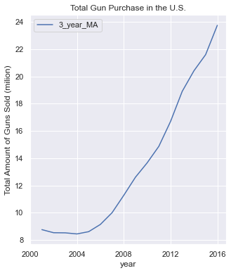

```python
## plot the moving average

fig1=df_gun_per_year.plot.line(y='3_year_MA', figsize=(5,6))
plt.title('Total Gun Purchase in the U.S.')
plt.xlabel('year')
plt.ylabel('Total Amount of Guns Sold (milion)')
plt.xticks([2000,2004,2008,2012,2016])

plt.show()
```

Total gun sale in the U.S. is soaring up for more than a decade. In 2004, it was around 8 million guns sold per year. The figure has almost tripled by 2016, reaching 24million guns sold a year.

#### State-wise trend

Now the state-wise trend will be investigated. The total amount of gun sold will be divided by the population of each state to make a fair comparison. The census table contains population data from 2010 and 2016 only. Thus the change of gun purchase per capita of these years will be compared.  
We first mad two dataframes: Total gun sale per state in the year 2010 and 2016.  
Following that, another dataframe which contains all the population information was made.  
These three dataframes are then combined.

```python
# make two dataframes of total gun purchase in 2010 & 2016
df_gun_2010=df_gun_v3[df_gun_v3.date.dt.year == 2010]
df_gun_2016=df_gun_v3[df_gun_v3.date.dt.year == 2016]
df_gun_2016.head()
```

|  | date | state | totals |
| --- | --- | --- | --- |
| 495 | 2016-12-01 | Alabama | 62014 |
| 496 | 2016-12-01 | Alaska | 8786 |
| 497 | 2016-12-01 | Arizona | 44887 |
| 498 | 2016-12-01 | Arkansas | 29926 |
| 499 | 2016-12-01 | California | 298161 |

```python
# now calculate the total sale per state of respective years.
df_gun_2010_per_state = df_gun_2010.groupby(['state',df_gun_2010.date.dt.year]).sum().reset_index()
## reset_index() to use a resulting grouped table as a new dataframe.
df_gun_2016_per_state = df_gun_2016.groupby(['state']).sum().reset_index()
df_gun_2010_per_state.head()
```

|  | state | date | totals |
| --- | --- | --- | --- |
| 0 | Alabama | 2010 | 308607 |
| 1 | Alaska | 2010 | 65909 |
| 2 | Arizona | 2010 | 206050 |
| 3 | Arkansas | 2010 | 191448 |
| 4 | California | 2010 | 816399 |

```python
# join df_gun_2010/2016_per_state tables
df_gun_per_state_comb = df_gun_2010_per_state.merge(df_gun_2016_per_state, left_on='state', right_on='state', how='inner')
# drop a date column and rename columns
df_gun_per_state_comb_v2 = df_gun_per_state_comb.drop(['date'],axis=1)
df_gun_sale_summary = df_gun_per_state_comb_v2.rename(columns={'totals_x':'gun_sale_10','totals_y':'gun_sale_16'})
df_gun_sale_summary.head()
```

|  | state | gun_sale_10 | gun_sale_16 |
| --- | --- | --- | --- |
| 0 | Alabama | 308607 | 616947 |
| 1 | Alaska | 65909 | 87647 |
| 2 | Arizona | 206050 | 416279 |
| 3 | Arkansas | 191448 | 266014 |
| 4 | California | 816399 | 2377167 |

Now the dataframe with population info was created.  
One thing to note: Person under 18 cannot purchase in the most state (* except Alaska, Minnesota, and Massachusetts), so it would be more accurate to calculate the gun sale per capita of people who are legal to buy them. Therefore, a new column containing a population percentage of people over 18 was added.  
ref. https://lawcenter.giffords.org/gun-laws/policy-areas/who-can-have-a-gun/minimum-age/

```python
# make a new df with population information
df_popl = df_census_v4.iloc[:,0:11]
## make the column for eligible age (i.e. 100 - percentage of person under 18)
df_popl['perc_popl_over_18_10'] = 100-df_popl.iloc[:,8]
df_popl['perc_popl_over_18_16'] = 100-df_popl.iloc[:,7]
df_popl['popl_over_18_10'] = df_popl['perc_popl_over_18_10']/100*df_popl.iloc[:,2] ## population in 2010
df_popl['popl_over_18_16'] = df_popl['perc_popl_over_18_16']/100*df_popl.iloc[:,1] ## population in 2016
df_popl.head()
```

|  | state | Population estimates, July 1, 2016, (V2016) | Population estimates base, April 1, 2010, (V2016) | Population, percent change - April 1, 2010 (estimates base) to July 1, 2016, (V2016) | Population, Census, April 1, 2010 | Persons under 5 years, percent, July 1, 2016, (V2016) | Persons under 5 years, percent, April 1, 2010 | Persons under 18 years, percent, July 1, 2016, (V2016) | Persons under 18 years, percent, April 1, 2010 | Persons 65 years and over, percent, July 1, 2016, (V2016) | Persons 65 years and over, percent, April 1, 2010 | perc_popl_over_18_10 | perc_popl_over_18_16 | popl_over_18_10 | popl_over_18_16 |
| --- | --- | --- | --- | --- | --- | --- | --- | --- | --- | --- | --- | --- | --- | --- | --- |
| 0 | Alabama | 4863300 | 4780131 | 1.7 | 4779736 | 6.0 | 6.4 | 22.6 | 23.7 | 16.1 | 13.8 | 76.3 | 77.4 | 3.647240e+06 | 3.764194e+06 |
| 1 | Alaska | 741894 | 710249 | 4.5 | 710231 | 7.3 | 7.6 | 25.2 | 26.4 | 10.4 | 7.7 | 73.6 | 74.8 | 5.227433e+05 | 5.549367e+05 |
| 2 | Arizona | 6931071 | 6392301 | 8.4 | 6392017 | 6.3 | 7.1 | 23.5 | 25.5 | 16.9 | 13.8 | 74.5 | 76.5 | 4.762264e+06 | 5.302269e+06 |
| 3 | Arkansas | 2988248 | 2916025 | 2.5 | 2915918 | 6.4 | 6.8 | 23.6 | 24.4 | 16.3 | 14.4 | 75.6 | 76.4 | 2.204515e+06 | 2.283021e+06 |
| 4 | California | 39250017 | 37254522 | 5.4 | 37253956 | 6.3 | 6.8 | 23.2 | 25.0 | 13.6 | 11.4 | 75.0 | 76.8 | 2.794089e+07 | 3.014401e+07 |

```python
## combine popl table
df_summary = df_gun_sale_summary.merge(df_popl.iloc[:,[0,13,14]], left_on='state', right_on='state', how='inner')
df_summary.head()
```

|  | state | gun_sale_10 | gun_sale_16 | popl_over_18_10 | popl_over_18_16 |
| --- | --- | --- | --- | --- | --- |
| 0 | Alabama | 308607 | 616947 | 3.647240e+06 | 3.764194e+06 |
| 1 | Alaska | 65909 | 87647 | 5.227433e+05 | 5.549367e+05 |
| 2 | Arizona | 206050 | 416279 | 4.762264e+06 | 5.302269e+06 |
| 3 | Arkansas | 191448 | 266014 | 2.204515e+06 | 2.283021e+06 |
| 4 | California | 816399 | 2377167 | 2.794089e+07 | 3.014401e+07 |

Using df_summary, gun sale per capita and its change over the period were calculated.

```python
# calculate sales_per_capita and increase percentage
df_summary['sales_per_legal_capita_10'] = df_summary['gun_sale_10']/df_summary['popl_over_18_10']
df_summary['sales_per_legal_capita_16'] = df_summary['gun_sale_16']/df_summary['popl_over_18_16']
df_summary['sales_change_perc'] = (df_summary.loc[:,'sales_per_legal_capita_16']
                                   -df_summary.loc[:,'sales_per_legal_capita_10'])/df_summary.loc[:,'sales_per_legal_capita_10']*100
```

```python
df_summary.head()
```

|  | state | gun_sale_10 | gun_sale_16 | popl_over_18_10 | popl_over_18_16 | sales_per_legal_capita_10 | sales_per_legal_capita_16 | sales_change_perc |
| --- | --- | --- | --- | --- | --- | --- | --- | --- |
| 0 | Alabama | 308607 | 616947 | 3.647240e+06 | 3.764194e+06 | 0.084614 | 0.163899 | 93.702131 |
| 1 | Alaska | 65909 | 87647 | 5.227433e+05 | 5.549367e+05 | 0.126083 | 0.157941 | 25.267186 |
| 2 | Arizona | 206050 | 416279 | 4.762264e+06 | 5.302269e+06 | 0.043267 | 0.078510 | 81.452765 |
| 3 | Arkansas | 191448 | 266014 | 2.204515e+06 | 2.283021e+06 | 0.086844 | 0.116518 | 34.170396 |
| 4 | California | 816399 | 2377167 | 2.794089e+07 | 3.014401e+07 | 0.029219 | 0.078860 | 169.895981 |

Using the dataframe above, top and bottom ten states with total gun sale in 2016 were plotted.

```
[Text(0.5, 0, '')]
```

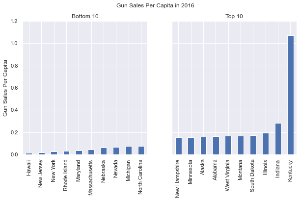

```python
top = df_summary.nlargest(10,'sales_per_legal_capita_16').sort_values(by=['sales_per_legal_capita_16'])
bottom = df_summary.nsmallest(10,'sales_per_legal_capita_16')

fig, (ax1,ax2) = plt.subplots(1,2, sharey=True, figsize=(10,5))
fig.suptitle('Gun Sales Per Capita in 2016')


bottom.plot.bar(x='state', y='sales_per_legal_capita_16', ax=ax1, legend=False)
ax1.set_ylim((0,1.2))
ax1.set_title('Bottom 10')
ax1.set(xlabel='',ylabel='Gun Sales Per Capita')


top.plot.bar(x='state', y='sales_per_legal_capita_16', ax=ax2, legend = False)
ax2.set_title('Top 10')
ax2.set(xlabel='')
```

It is immediately noticeable that gun sales in Kentucky in 2016 were by far the largest. On average, every person who is legal to purchase a gun had bought a gun. The figure is three times more than Indiana who came second in the rank. There seems to be no significant difference in the rest of the top 10.

The following plot shows the percentage change in a gun sale from 2010 to 2016

```
[Text(0.5, 0, '')]
```

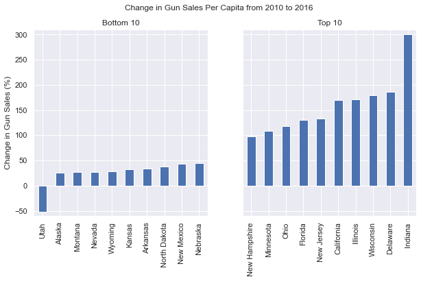

```python
top = df_summary.nlargest(10,'sales_change_perc').sort_values(by=['sales_change_perc'])
bottom = df_summary.nsmallest(10,'sales_change_perc')

fig, (ax1,ax2) = plt.subplots(1,2, sharey=True, figsize=(10,5))
fig.suptitle('Change in Gun Sales Per Capita from 2010 to 2016')


bottom.plot.bar(x='state', y='sales_change_perc', ax=ax1, legend=False)
ax1.set_ylim((-60,310))
ax1.set_title('Bottom 10')
ax1.set(xlabel='',ylabel='Change in Gun Sales (%)')


top.plot.bar(x='state', y='sales_change_perc', ax=ax2, legend = False)
ax2.set_title('Top 10')
ax2.set(xlabel='')
```

Utah is the only state which saw a decrease in the total gun sale. All the other states recorded an increase in gun sale. Indiana saw the rise by 300%, by far the most significant figure. The second to the fifth place has more than 150% increase as well.  
What is interesting is that the states who saw a substantial increase and small increase are geographically very close to each other. The heat map of the change in the gun sale was plotted to illustrate the point. To do this, Plotly, a graphical library, was used. https://plotly.com/python/choropleth-maps/

```python
## plotly would require to reference states by its two character abbreviation.
state_abb = pd.read_csv('state_abb.csv')
state_abb.drop('Abbrev',axis=1, inplace=True) # only need two letter state ID, and another form of abbrev is not needed
state_abb.rename(columns={'State':'state'}, inplace=True) # rename column to be consistent with df_summary
```

```python
## join state_abb dataframe to the summary dataframe
df_summary_v2 = df_summary.merge(state_abb, left_on='state', right_on='state', how='inner')
df_summary_v2
```

|  | state | gun_sale_10 | gun_sale_16 | popl_over_18_10 | popl_over_18_16 | sales_per_legal_capita_10 | sales_per_legal_capita_16 | sales_change_perc | Code |
| --- | --- | --- | --- | --- | --- | --- | --- | --- | --- |
| 0 | Alabama | 308607 | 616947 | 3.647240e+06 | 3.764194e+06 | 0.084614 | 0.163899 | 93.702131 | AL |
| 1 | Alaska | 65909 | 87647 | 5.227433e+05 | 5.549367e+05 | 0.126083 | 0.157941 | 25.267186 | AK |
| 2 | Arizona | 206050 | 416279 | 4.762264e+06 | 5.302269e+06 | 0.043267 | 0.078510 | 81.452765 | AZ |
| 3 | Arkansas | 191448 | 266014 | 2.204515e+06 | 2.283021e+06 | 0.086844 | 0.116518 | 34.170396 | AR |
| 4 | California | 816399 | 2377167 | 2.794089e+07 | 3.014401e+07 | 0.029219 | 0.078860 | 169.895981 | CA |
| 5 | Colorado | 300820 | 540514 | 3.802169e+06 | 4.277301e+06 | 0.079118 | 0.126368 | 59.720942 | CO |
| 6 | Connecticut | 179595 | 317692 | 2.755642e+06 | 2.821821e+06 | 0.065174 | 0.112584 | 72.744971 | CT |
| 7 | Delaware | 19240 | 59430 | 6.923087e+05 | 7.473710e+05 | 0.027791 | 0.079519 | 186.130509 | DE |
| 8 | Florida | 559347 | 1435340 | 1.479921e+07 | 1.646934e+07 | 0.037796 | 0.087152 | 130.587605 | FL |
| 9 | Georgia | 333247 | 612985 | 7.198689e+06 | 7.794640e+06 | 0.046293 | 0.078642 | 69.879485 | GA |
| 10 | Hawaii | 10533 | 16681 | 1.056954e+06 | 1.119989e+06 | 0.009965 | 0.014894 | 49.455671 | HI |
| 11 | Idaho | 92031 | 156343 | 1.138114e+06 | 1.245524e+06 | 0.080863 | 0.125524 | 55.230861 | ID |
| 12 | Illinois | 695300 | 1924070 | 9.700670e+06 | 9.869987e+06 | 0.071675 | 0.194942 | 171.978019 | IL |
| 13 | Indiana | 345650 | 1436725 | 4.876070e+06 | 5.054386e+06 | 0.070887 | 0.284253 | 300.994674 | IN |
| 14 | Iowa | 124738 | 202277 | 2.318667e+06 | 2.404310e+06 | 0.053797 | 0.084131 | 56.385250 | IA |
| 15 | Kansas | 144156 | 196548 | 2.125581e+06 | 2.192096e+06 | 0.067820 | 0.089662 | 32.206874 | KS |
| 16 | Kentucky | 2385579 | 3676847 | 3.315259e+06 | 3.425344e+06 | 0.719575 | 1.073424 | 49.174644 | KY |
| 17 | Louisiana | 239204 | 391869 | 3.413710e+06 | 3.567429e+06 | 0.070072 | 0.109846 | 56.763033 | LA |
| 18 | Maine | 65988 | 111582 | 1.053393e+06 | 1.077167e+06 | 0.062643 | 0.103588 | 65.362343 | ME |
| 19 | Maryland | 88162 | 165367 | 4.422720e+06 | 4.668763e+06 | 0.019934 | 0.035420 | 77.686753 | MD |
| 20 | Massachusetts | 115904 | 226212 | 5.126938e+06 | 5.435800e+06 | 0.022607 | 0.041615 | 84.082204 | MA |
| 21 | Michigan | 348200 | 579605 | 7.541590e+06 | 7.734146e+06 | 0.046171 | 0.074941 | 62.313241 | MI |
| 22 | Minnesota | 297390 | 651599 | 4.020374e+06 | 4.233803e+06 | 0.073971 | 0.153904 | 108.060617 | MN |
| 23 | Mississippi | 169873 | 276161 | 2.211237e+06 | 2.268443e+06 | 0.076823 | 0.121740 | 58.469378 | MS |
| 24 | Missouri | 349672 | 632319 | 4.563563e+06 | 4.703796e+06 | 0.076623 | 0.134427 | 75.440945 | MO |
| 25 | Montana | 101095 | 136337 | 7.658064e+05 | 8.152506e+05 | 0.132011 | 0.167233 | 26.681128 | MT |
| 26 | Nebraska | 58283 | 88663 | 1.367924e+06 | 1.434151e+06 | 0.042607 | 0.061823 | 45.100061 | NE |
| 27 | Nevada | 104789 | 147992 | 2.036321e+06 | 2.263845e+06 | 0.051460 | 0.065372 | 27.034641 | NV |
| 28 | New Hampshire | 79940 | 165164 | 1.029473e+06 | 1.074510e+06 | 0.077651 | 0.153711 | 97.950019 | NH |
| 29 | New Jersey | 50522 | 121853 | 6.725844e+06 | 6.958797e+06 | 0.007512 | 0.017511 | 133.113983 | NJ |
| 30 | New Mexico | 109069 | 161216 | 1.540280e+06 | 1.589895e+06 | 0.070811 | 0.101400 | 43.198328 | NM |
| 31 | New York | 241495 | 404772 | 1.505679e+07 | 1.555929e+07 | 0.016039 | 0.026015 | 62.197831 | NY |
| 32 | North Carolina | 331637 | 601445 | 7.256659e+06 | 7.843467e+06 | 0.045701 | 0.076681 | 67.788252 | NC |
| 33 | North Dakota | 47083 | 72036 | 5.226032e+05 | 5.813492e+05 | 0.090093 | 0.123912 | 37.537291 | ND |
| 34 | Ohio | 393250 | 875724 | 8.802523e+06 | 9.001139e+06 | 0.044675 | 0.097290 | 117.775090 | OH |
| 35 | Oklahoma | 233909 | 364590 | 2.821214e+06 | 2.962289e+06 | 0.082911 | 0.123077 | 48.445338 | OK |
| 36 | Oregon | 184835 | 324708 | 2.965250e+06 | 3.225650e+06 | 0.062334 | 0.100664 | 61.492647 | OR |
| 37 | Pennsylvania | 626677 | 1143220 | 9.908228e+06 | 1.011232e+07 | 0.063248 | 0.113052 | 78.743852 | PA |
| 38 | Rhode Island | 14835 | 27758 | 8.286638e+05 | 8.483101e+05 | 0.017902 | 0.032722 | 82.778181 | RI |
| 39 | South Carolina | 201628 | 402978 | 3.543064e+06 | 3.864712e+06 | 0.056908 | 0.104271 | 83.228235 | SC |
| 40 | South Dakota | 63151 | 111921 | 6.114604e+05 | 6.525523e+05 | 0.103279 | 0.171513 | 66.067399 | SD |
| 41 | Tennessee | 411024 | 714774 | 4.848572e+06 | 5.148024e+06 | 0.084772 | 0.138844 | 63.785258 | TN |
| 42 | Texas | 968071 | 1721726 | 1.828121e+07 | 2.056260e+07 | 0.052954 | 0.083731 | 58.118956 | TX |
| 43 | Utah | 553134 | 294907 | 1.893263e+06 | 2.129749e+06 | 0.292159 | 0.138470 | -52.604488 | UT |
| 44 | Vermont | 24276 | 39417 | 4.962126e+05 | 5.059211e+05 | 0.048923 | 0.077911 | 59.254389 | VT |
| 45 | Virginia | 320783 | 528369 | 6.144799e+06 | 6.544387e+06 | 0.052204 | 0.080736 | 54.655280 | VA |
| 46 | Washington | 335342 | 713996 | 5.144277e+06 | 5.655488e+06 | 0.065187 | 0.126248 | 93.669880 | WA |
| 47 | West Virginia | 159550 | 242350 | 1.465732e+06 | 1.455726e+06 | 0.108853 | 0.166480 | 52.939981 | WV |
| 48 | Wisconsin | 194797 | 561819 | 4.345089e+06 | 4.490056e+06 | 0.044832 | 0.125125 | 179.100777 | WI |
| 49 | Wyoming | 47709 | 63594 | 4.284629e+05 | 4.467373e+05 | 0.111349 | 0.142352 | 27.842982 | WY |

```python
## import plotly
import plotly.graph_objects as go

fig = go.Figure(data=go.Choropleth(
    locations = df_summary_v2['Code'],
    z=df_summary_v2['sales_change_perc'],
    locationmode='USA-states',
    colorscale='Portland',
    colorbar_title='Gun Purchase Change (%)',))

fig.update_layout(
    geo_scope='usa',)

fig.show()
```

[interactive chart not shown]

```python
## comparison with the standard federal regions
from IPython.display import Image
from IPython.core.display import HTML
Image(url= "https://www.hhs.gov/sites/default/files/iea/images/regionsmap.jpg")
```

[figure not shown]

### 2) Contributing factors to gun sale

In this part, the contributing factors to the total amount of gun sales.  
As the first step, the summary dataframe made in part 1) is merged with the census table, and correlation of the gun sale and each attribute are determined.

```python
df_census_gun_sale = df_census_v4.merge(df_summary_v2.iloc[:,np.r_[0,3:8]], left_on='state', right_on='state', how='inner')
df_census_gun_sale.head()
```

|  | state | Population estimates, July 1, 2016, (V2016) | Population estimates base, April 1, 2010, (V2016) | Population, percent change - April 1, 2010 (estimates base) to July 1, 2016, (V2016) | Population, Census, April 1, 2010 | Persons under 5 years, percent, July 1, 2016, (V2016) | Persons under 5 years, percent, April 1, 2010 | Persons under 18 years, percent, July 1, 2016, (V2016) | Persons under 18 years, percent, April 1, 2010 | Persons 65 years and over, percent, July 1, 2016, (V2016) | ... | Nonminority-owned firms, 2012 | Veteran-owned firms, 2012 | Nonveteran-owned firms, 2012 | Population per square mile, 2010 | Land area in square miles, 2010 | popl_over_18_10 | popl_over_18_16 | sales_per_legal_capita_10 | sales_per_legal_capita_16 | sales_change_perc |
| --- | --- | --- | --- | --- | --- | --- | --- | --- | --- | --- | --- | --- | --- | --- | --- | --- | --- | --- | --- | --- | --- |
| 0 | Alabama | 4863300 | 4780131 | 1.7 | 4779736 | 6.0 | 6.4 | 22.6 | 23.7 | 16.1 | ... | 272651 | 41943 | 316984 | 94.4 | 50645.33 | 3.647240e+06 | 3.764194e+06 | 0.084614 | 0.163899 | 93.702131 |
| 1 | Alaska | 741894 | 710249 | 4.5 | 710231 | 7.3 | 7.6 | 25.2 | 26.4 | 10.4 | ... | 51147 | 7953 | 56091 | 1.2 | 570640.95 | 5.227433e+05 | 5.549367e+05 | 0.126083 | 0.157941 | 25.267186 |
| 2 | Arizona | 6931071 | 6392301 | 8.4 | 6392017 | 6.3 | 7.1 | 23.5 | 25.5 | 16.9 | ... | 344981 | 46780 | 427582 | 56.3 | 113594.08 | 4.762264e+06 | 5.302269e+06 | 0.043267 | 0.078510 | 81.452765 |
| 3 | Arkansas | 2988248 | 2916025 | 2.5 | 2915918 | 6.4 | 6.8 | 23.6 | 24.4 | 16.3 | ... | 189029 | 25915 | 192988 | 56.0 | 52035.48 | 2.204515e+06 | 2.283021e+06 | 0.086844 | 0.116518 | 34.170396 |
| 4 | California | 39250017 | 37254522 | 5.4 | 37253956 | 6.3 | 6.8 | 23.2 | 25.0 | 13.6 | ... | 1819107 | 252377 | 3176341 | 239.1 | 155779.22 | 2.794089e+07 | 3.014401e+07 | 0.029219 | 0.078860 | 169.895981 |

5 rows × 68 columns

As it was found out, Kentucky had abnormally high gun sales and to eliminate the effect of it, the dataframe without Kentucky was also prepared.

```python
df_census_gun_sale_without_ky = df_census_gun_sale[df_census_gun_sale['state']!='Kentucky']
df_census_gun_sale_without_ky.head()
```

|  | state | Population estimates, July 1, 2016, (V2016) | Population estimates base, April 1, 2010, (V2016) | Population, percent change - April 1, 2010 (estimates base) to July 1, 2016, (V2016) | Population, Census, April 1, 2010 | Persons under 5 years, percent, July 1, 2016, (V2016) | Persons under 5 years, percent, April 1, 2010 | Persons under 18 years, percent, July 1, 2016, (V2016) | Persons under 18 years, percent, April 1, 2010 | Persons 65 years and over, percent, July 1, 2016, (V2016) | ... | Nonminority-owned firms, 2012 | Veteran-owned firms, 2012 | Nonveteran-owned firms, 2012 | Population per square mile, 2010 | Land area in square miles, 2010 | popl_over_18_10 | popl_over_18_16 | sales_per_legal_capita_10 | sales_per_legal_capita_16 | sales_change_perc |
| --- | --- | --- | --- | --- | --- | --- | --- | --- | --- | --- | --- | --- | --- | --- | --- | --- | --- | --- | --- | --- | --- |
| 0 | Alabama | 4863300 | 4780131 | 1.7 | 4779736 | 6.0 | 6.4 | 22.6 | 23.7 | 16.1 | ... | 272651 | 41943 | 316984 | 94.4 | 50645.33 | 3.647240e+06 | 3.764194e+06 | 0.084614 | 0.163899 | 93.702131 |
| 1 | Alaska | 741894 | 710249 | 4.5 | 710231 | 7.3 | 7.6 | 25.2 | 26.4 | 10.4 | ... | 51147 | 7953 | 56091 | 1.2 | 570640.95 | 5.227433e+05 | 5.549367e+05 | 0.126083 | 0.157941 | 25.267186 |
| 2 | Arizona | 6931071 | 6392301 | 8.4 | 6392017 | 6.3 | 7.1 | 23.5 | 25.5 | 16.9 | ... | 344981 | 46780 | 427582 | 56.3 | 113594.08 | 4.762264e+06 | 5.302269e+06 | 0.043267 | 0.078510 | 81.452765 |
| 3 | Arkansas | 2988248 | 2916025 | 2.5 | 2915918 | 6.4 | 6.8 | 23.6 | 24.4 | 16.3 | ... | 189029 | 25915 | 192988 | 56.0 | 52035.48 | 2.204515e+06 | 2.283021e+06 | 0.086844 | 0.116518 | 34.170396 |
| 4 | California | 39250017 | 37254522 | 5.4 | 37253956 | 6.3 | 6.8 | 23.2 | 25.0 | 13.6 | ... | 1819107 | 252377 | 3176341 | 239.1 | 155779.22 | 2.794089e+07 | 3.014401e+07 | 0.029219 | 0.078860 | 169.895981 |

5 rows × 68 columns

```python
### Determine the correlation matrix
corr_matrix_without_ky = df_census_gun_sale_without_ky.corr()
```

```python
## factors with correlation larger than 0.4 (or smaller than -0.4)
corr_sales = corr_matrix_without_ky['sales_per_legal_capita_16'].sort_values(ascending=False).where(lambda x: abs(x)>0.40).dropna()
corr_sales
```

```
sales_per_legal_capita_16                                                                 1.000000
sales_per_legal_capita_10                                                                 0.568853
Owner-occupied housing unit rate, 2011-2015                                               0.479651
White alone, not Hispanic or Latino, percent, July 1, 2016,  (V2016)                      0.446756
Mean travel time to work (minutes), workers age 16 years+, 2011-2015                     -0.402454
Asian alone, percent, July 1, 2016,  (V2016)                                             -0.437326
Median value of owner-occupied housing units, 2011-2015                                  -0.465069
Language other than English spoken at home, percent of persons age 5 years+, 2011-2015   -0.468357
Population per square mile, 2010                                                         -0.484104
Median selected monthly owner costs -with a mortgage, 2011-2015                          -0.498908
Median gross rent, 2011-2015                                                             -0.514621
Foreign born persons, percent, 2011-2015                                                 -0.560046
Name: sales_per_legal_capita_16, dtype: float64
```

Some of these factors seem to be closely related to each other and might be redundant to include all of them (such as Median monthly owner costs and median gross rent). The following heat map shows the correlation between each attribute.

```python
corr_sales_cols = corr_sales.index[2:].to_list()

corr_matrix_v2 = df_census_gun_sale_without_ky.loc[:,corr_sales_cols].corr()
```

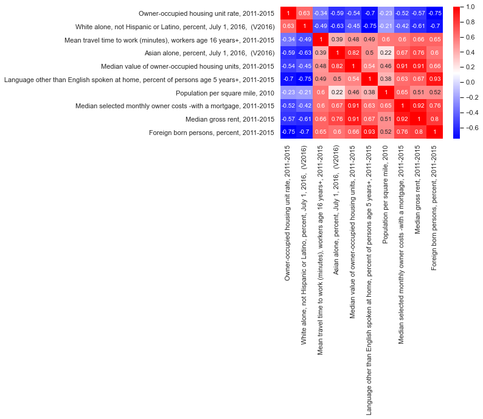

```python
sns.heatmap(corr_matrix_v2, annot=True, cmap = 'bwr')
```

The above heatmap shows the correlation between each attribute. Not surprisingly, three of housing-related factors (Median value of owner-occupied housing units, Median selected monthly owner costs -with a mortgage, and Median gross rent) are highly correlated.  
Another highly correlated factors are Language other than English spoken at home, percent and Foreign-born person.  
For simplicity of analysis, factors with smaller correlation to the gun sales were dropped.

```python
corr_sales_cols_v2 = ['Owner-occupied housing unit rate, 2011-2015',
 'White alone, not Hispanic or Latino, percent, July 1, 2016,  (V2016)',
 'Mean travel time to work (minutes), workers age 16 years+, 2011-2015',
 'Asian alone, percent, July 1, 2016,  (V2016)',
 'Population per square mile, 2010',
 'Median gross rent, 2011-2015',
 'Foreign born persons, percent, 2011-2015']
```

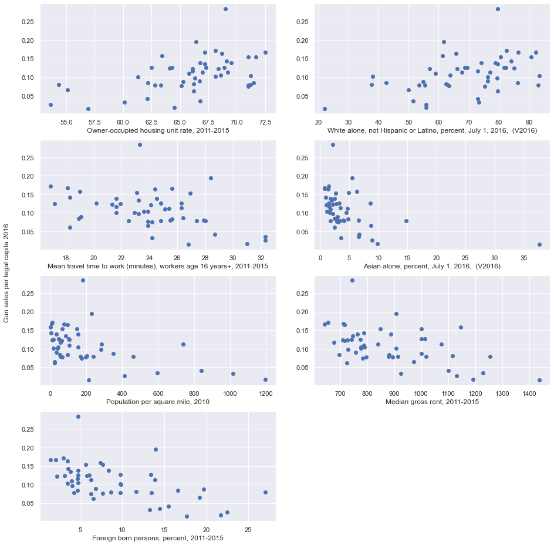

```python
# Plot scatter plots of highly correlated factors against the gun sales per capita.

fig=plt.figure(figsize=(13,13))
for col,i in zip(corr_sales_cols_v2,range(1,9)):
    ax = fig.add_subplot(4,2,i, xlabel=col)
    ax.scatter(df_census_gun_sale_without_ky[col],df_census_gun_sale_without_ky['sales_per_legal_capita_16'])
plt.tight_layout()
fig.text(-0.02,0.5, 'Gun sales per legal capita 2016', va='center', rotation ='vertical', fontsize=12)
plt.show()
```

These are some factors that might have affects the gun sales in the U.S..

```python
corr_sales[corr_sales_cols_v2]
```

```
Owner-occupied housing unit rate, 2011-2015                             0.479651
White alone, not Hispanic or Latino, percent, July 1, 2016,  (V2016)    0.446756
Mean travel time to work (minutes), workers age 16 years+, 2011-2015   -0.402454
Asian alone, percent, July 1, 2016,  (V2016)                           -0.437326
Population per square mile, 2010                                       -0.484104
Median gross rent, 2011-2015                                           -0.514621
Foreign born persons, percent, 2011-2015                               -0.560046
Name: sales_per_legal_capita_16, dtype: float64
```

Population demography might contribute to the gun sales, as three factors (Percentage of White alone, Asian Alone and foreign-born persons) are listed above.  
Housing situation (rate of owner-occupied housing unit, Median gross rent) is another area worth looking into. Combine this with the rest of the factors (mean travel time to work and population density), the geographical situation (urban vs rural) possibly corresponds to the gun sales.

## Conclusions

In the first part of the analysis, I have looked into the general gun sale trend in the U.S. Gun sales in the U.S. has been steadily increasing since 2004. This coincides with the expiration of Federal Assault Weapon Ban in September 2004. Since then the total gun sale per year has tripled, and the figure reached 24million by 2016.  
The state-wise analysis has shown that the gun sale in Kentucky is abnormally high. Investigate further into the reason behind this figure might be useful in determining the factors that contribute to gun sales in general. Gun sales have increased in every state except Utah from 2010 to 2016. States that saw a significant increase concentrate on the region 5 of the standard federal region, meanwhile states from region 8 had the lower increase rate. As the situation (not only the gun regulation but population demographic to the local economy) vastly differs from state to state, analysis in smaller subgroups, i.e. the regional or state, might yield more insightful results.  
In the second part, the factors that might have influenced the gun sales per capita in 2016 were studied. The result indicated that the population demography possibly plays a role in gun sales. It has also been indicated the influence of geographical factors again.  
This analysis was a glance into the gun sale situation in the U.S. and by no means a definitive result. However, the results found from this analyst hint at the direction of where the further detailed analysis is required.